# Predicting Transcription Factor Binding

using ChIP-seq Data

Hamish Patten

2022-09-02

## Introduction

The aim of this mini-project is to predict which DNA sequences will bind to a given Transcription Factor (TF). Using various Machine Learning models, we will build a classifier that identifies which sequence features are predictive of gene-TF binding for this specific TF. The data used for this research is from ChIP-sequencing experiments. We will not explain this concept in this report, but ask the reader to explore themselves if they are not familiar with the subject.

## Data

We are provided with two datasets. The first is a list of the top-1000 DNA sequences that were inferred from the ChIP-seq data, ranked by the intensity of the signal of the region the sequence was inferred from. The second is a list of 5000 DNA sequences that were inferred to not bind with the specific TF.

```r
# Load in the ChIP-seq datasets
peaks<-LoadPeaks()
```

```
## [1] "Removing random sequences"
## [1] "Removing chrUn sequences"
```

```r
# Load also the shuffle data
shuffle<-LoadShuffle()
```

```r
peaks%>%dplyr::select(-dna)%>%head()
```

|  | GenomeBuild | Chromosome | StartP | EndP | FoldEnrich | Namer | pScore | lengthDNA |
| --- | --- | --- | --- | --- | --- | --- | --- | --- |
| 1 | hg19 | X | 152665682 | 152665785 | 25.097 | 1000053 | 1 | 103 |
| 2 | hg19 | X | 100023865 | 100023966 | 24.868 | 1000044 | 1 | 101 |
| 3 | hg19 | X | 132926613 | 132926706 | 24.241 | 1000071 | 2 | 93 |
| 4 | hg19 | X | 153763152 | 153763262 | 23.996 | 1000063 | 1 | 110 |
| 5 | hg19 | X | 73770289 | 73770396 | 23.278 | 1000123 | 2 | 107 |
| 6 | hg19 | X | 12965021 | 12965133 | 22.615 | 1000303 | 1 | 112 |

The most important variables that we are interested in are the chromosomes, the start and end position (StartP and EndP, resp.), the length of the DNA sequence $|EndP - StartP|$, and the strength of the ChIP-seq signal of the gene, which I have reason to believe is normalised by the fold enrichment method. The other variables are not 100% understood, and are apparently not all that relevant.

### Exploratory Data Analysis

Let’s have a look at some important plots of the peak data. Firstly, let’s look at the (fold enrichment) Chip-seq signal strength, per chromosome:

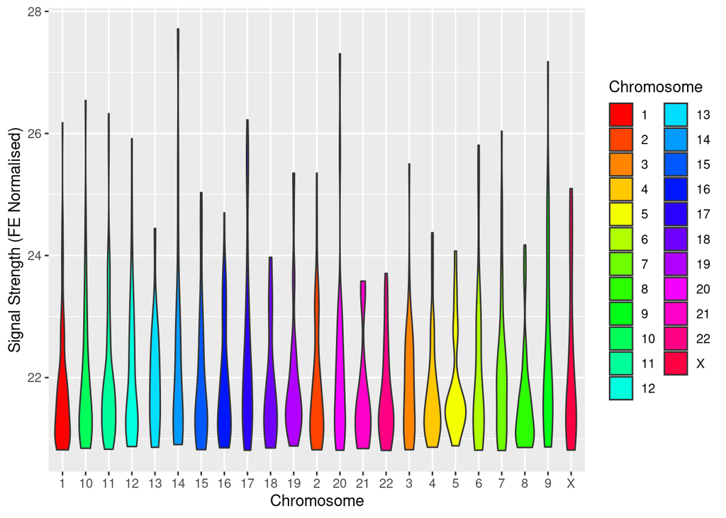

```r
peaks%>%ggplot(aes(x=Chromosome, y=FoldEnrich))+geom_violin(aes(fill=Chromosome)) +
  ylab("Signal Strength (FE Normalised)") +
  # theme(axis.ticks.x = element_blank(),axis.text.x = element_blank()) +
  scale_fill_manual(breaks=c(as.character(1:22),"X"), values=rainbow(23))
```

Why are there no Y chromosomes? Does this indicate that the experiments had an entirely female-demography? This could be an example of demographic bias. Let’s check the numbers per chromosome:

```r
peaks%>%group_by(Chromosome)%>%summarise(Counts=length(Chromosome))%>%knitr::kable(align="l")
```

| Chromosome | Counts |
| --- | --- |
| 1 | 104 |
| 10 | 44 |
| 11 | 74 |
| 12 | 48 |
| 13 | 19 |
| 14 | 38 |
| 15 | 42 |
| 16 | 54 |
| 17 | 74 |
| 18 | 14 |
| 19 | 46 |
| 2 | 75 |
| 20 | 28 |
| 21 | 12 |
| 22 | 42 |
| 3 | 50 |
| 4 | 27 |
| 5 | 24 |
| 6 | 25 |
| 7 | 61 |
| 8 | 34 |
| 9 | 38 |
| X | 21 |

We should be careful that the modelling later on is not heavily influence by the different count sizes. For example, chr1 is overrepresented and chr21 underrepresented. Let us first group the shuffle and peaks data together.

```r
shuffle$Chromosome<-NA; shuffle$FoldEnrich<-0; shuffle$Namer<-NA; shuffle$pScore<-0; shuffle$Bound<-F
peaks$Bound<-T
ALL<-rbind(peaks,shuffle)
```

Now let’s use Factor Analysis of Mixed Data (FAMD) to try to get some insight into which variables distinguish the genes from one another, forgetting the binding strength and p-score signal-to-control values for the time being.

```r
fammyD_all<-ALL%>%dplyr::select(Chromosome,StartP,EndP,lengthDNA,Bound)%>%
  FAMD(ncp = 2,sup.var = 5)
```

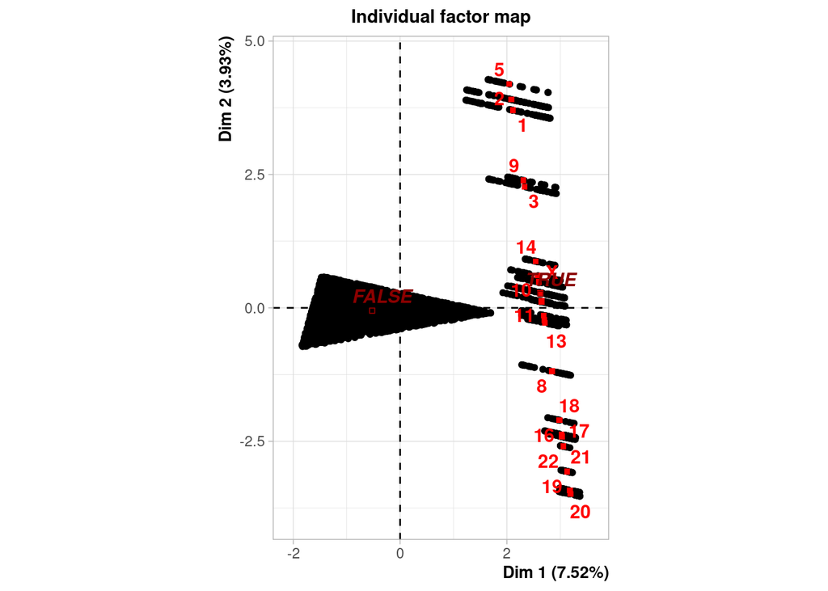

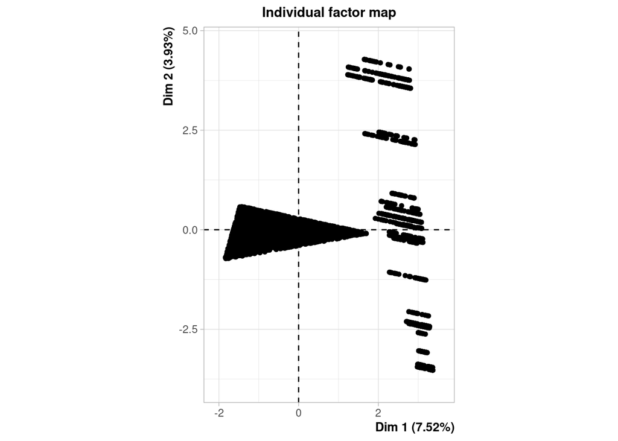

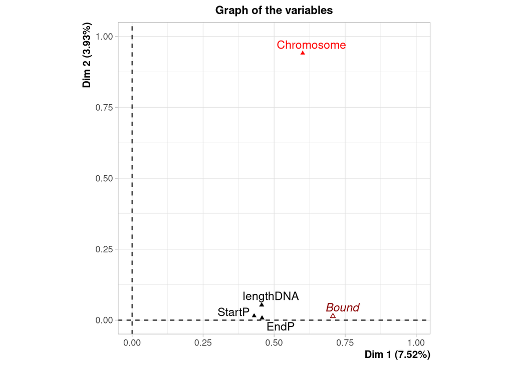

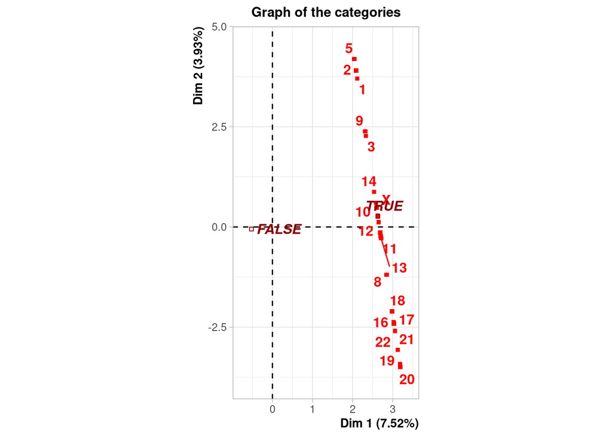

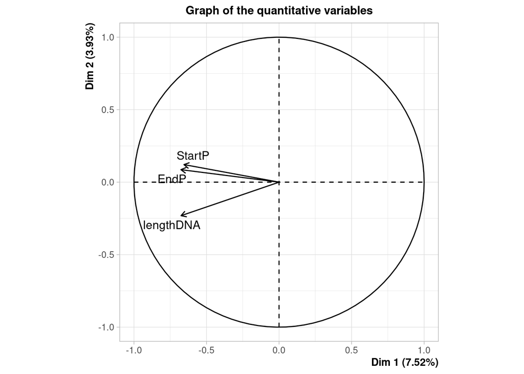

The conclusion of the FAMD is that the chromosome looks like a particularly crucial feature to include when explaining the differences between the different genes. The start and end positions of the gene also seem to contribute significantly to the first-dimension of the FAMD - the most important one, indicating that this is a strong feature that acts to separate the different genes from one another. What happens if we normalise the start and end position *per chromosome*? Let’s see if that is more predictive of whether a gene will bind or not to the TF.

```r
ALL%<>%group_by(Chromosome)%>%mutate(modStart=StartP/min(StartP),modEnd=EndP/min(EndP))%>%ungroup()
fammyD_posA<-ALL%>%dplyr::select(Chromosome,modStart,modEnd,lengthDNA,Bound)%>%FAMD(ncp = 2,sup.var = 5)
```

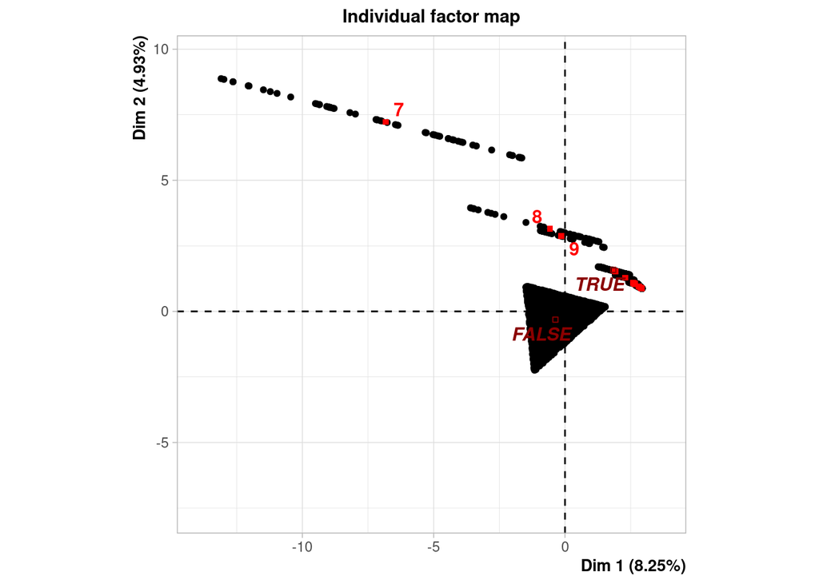

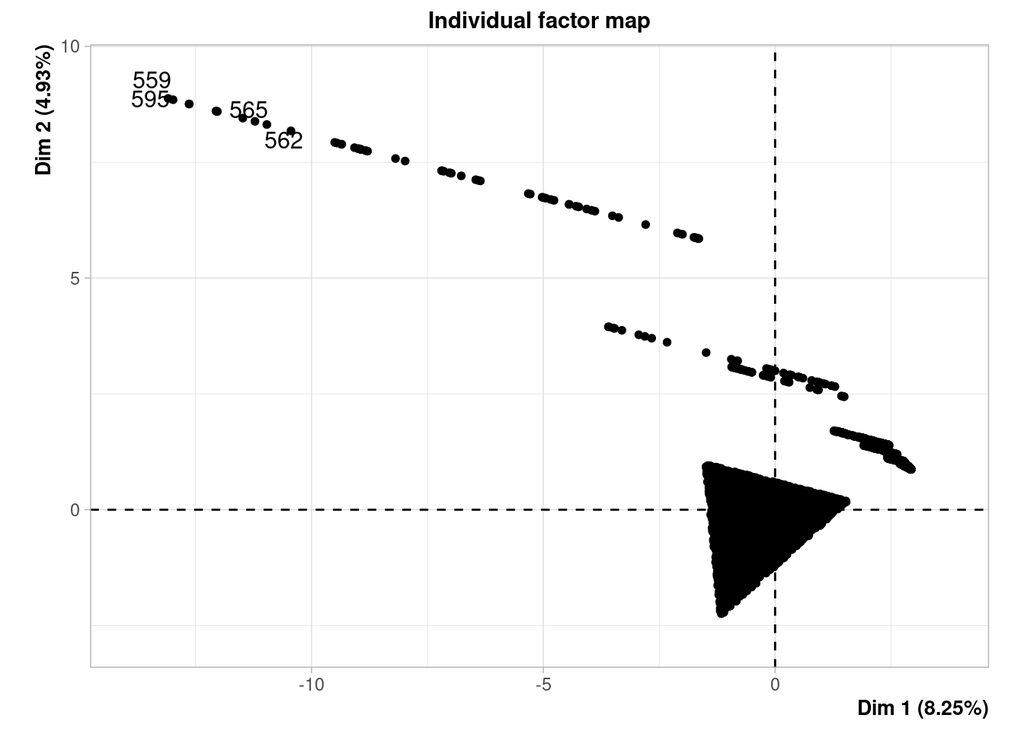

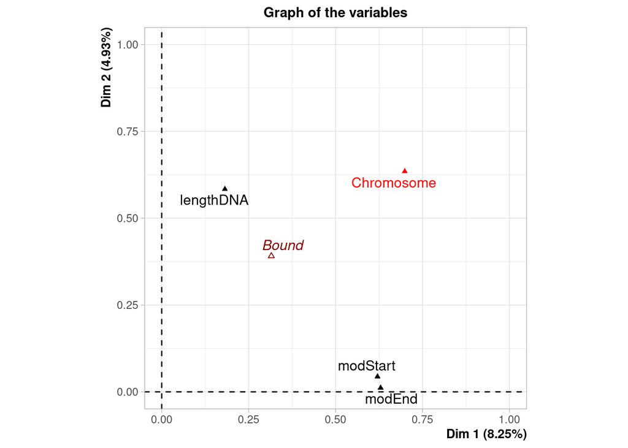

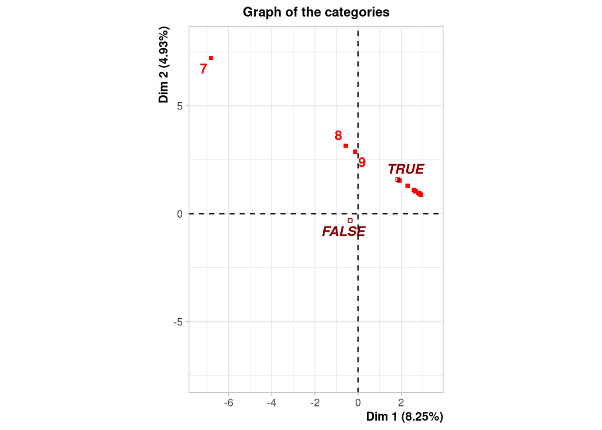

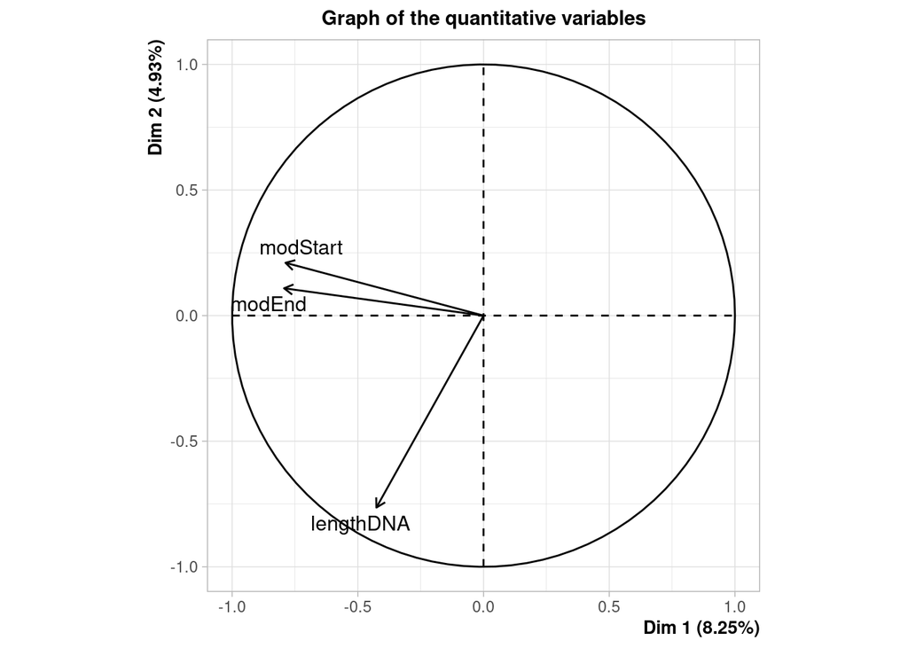

This plot indicates that this FAMD has created a division between the 1000-peak-genes and the control genes whereby this difference is *orthogonal to the chromosome embedding*. This means that we can now setup our model with numeric data only, at least for the first step, which greatly facilitates pre-processing. Let’s use this for the first phase of model development.

## Statistical Modelling

For this work, we will compare two different models. The first, which took me around 15 minutes to implement, is the Support Vector Machine, which is applied to the dataset without the DNA sequence involved at all. The second step is to train a Convolutional Neural Network (CNN) on the DNA sequence data. In the final model, I combine both the DNA sequence data and the length of the DNA variable into one single model. A summary of the models studied is as follows:

1. Support Vector Machine
   - with linear kernel (varying cost)
   - with radial kernel (varying sigma and cost)
   - with polynomial kernel (varying degree, scale and cost)
2. Convolutional Neural Network
   - Varying the one-hot permutations of A,C,G,T
   - Choice of optimiser: Stochastic Gradient Descent, ADAM and Ada-Delta
   - Varying hyperparameter choice of the CNN
   - Applying different layers to the CNN model

### Support Vector Machine

For the SVM analysis, we do not include the DNA sequence data, only the gene-specific covariates that also came in the file. We train two models on only three variables. In both models, we use the length of the DNA sequence as an input. In the first model, we also use the start and end position of the gene, not relativised to the chromosome that it was detected to be attached to. The second model uses the relativised start and end positions of the gene, relative to the chromosome. Note that the ‘unbound’ gene sequences (provided from the shuffle file) do not have an associated chromosome, and so are normalised amongst themselves, which may not be appropriate.

As shown in the numbered list in the previous section, we apply linear, radial and polygon kernels in the SVM models. Stratified, repeated (10 times) 5-fold Cross-Validation is used to illustrate model performance. The metric used is the AUC (Area Under the Receiver Operating Characteristic - ROC - Curve). The results of the SVM models are as follows:

```r
svmDNA<-readRDS(paste0(dir,"/Results/SVM.RData"))
svmDNA %>% group_by(model,data)%>%summarise(AUC=mean(ROC),.groups="drop")%>%
  knitr::kable(col.names = c("Model","Chromosome-Relative","Average AUC"))
```

| Model | Chromosome-Relative | Average AUC |
| --- | --- | --- |
| svmLinear | FALSE | 0.9981386 |
| svmLinear | TRUE | 1.0000000 |
| svmPoly | FALSE | 0.9859177 |
| svmPoly | TRUE | 0.9661523 |
| svmRadial | FALSE | 0.9987702 |
| svmRadial | TRUE | 0.9983155 |

### Convolutional Neural Network

This CNN model consists of building layers of the neural network, some are 2D convolutional, some are dense layers. The setup is varied throughout the work. The ‘baseline’ setup is shown in the code below:

```r
cnn_model <- keras_model_sequential() %>%
  # Convolutional layer, including ReLu Activation Function
  layer_conv_2d(filters = 30, kernel_size = c(4,24),
                activation = 'relu', input_shape = c(4,174,1)) %>%
  # Max pooling
  layer_max_pooling_2d(pool_size = c(1, 2)) %>%
  # Prevent overfitting with a dropout layer
  layer_dropout(rate = 0.2) %>%
  # Normalisation to ensure no information is wasted
  layer_batch_normalization() %>%
  # We finish the convolutional work and move to 1D
  layer_flatten() %>%
  # Prepare for the densely-connected network, including ReLu Activation Function
  layer_dense(units = 30, activation = 'relu') %>%
  # Add another dropout layer
  layer_dropout(rate = 0.5) %>%
  # Softmax Activation Function to create probabilities which can build the AUC
  layer_dense(units = 2, activation = 'softmax')
```

```
## Loaded Tensorflow version 2.9.1
```

When we run our model, we use stratified, 10-times repeated 5-fold cross-validation. The performance metrics that are used are the AUC, the precision and the recall. Before starting our first simulation, we need to make one-hot arrays for both the peaks and the shuffle data, shown in the figure below. Before we do, let’s also minimise the computation by choosing a minimum base length as the maximum sequence length out of both the shuffle and peak datasets. Although the minimum base length should be between 200-300 (the limit of the ChIP-seq experimental technology), we take the max length instead to save computation. Let’s print out the length, and also have a quick preview of what the one-hot array looks like (trimmmed to the first 10 columns)

```r
maxL<-max(max(str_length(peaks$dna)),max(str_length(shuffle$dna))); print(maxL)
```

```
## [1] 174
```

```r
OneHpeaks<-ConvOneHot(peaks$dna,maxL)
OneHpeaks[1,,1:10]
```

```
##      [,1] [,2] [,3] [,4] [,5] [,6] [,7] [,8] [,9] [,10]
## [1,]    0    0    0    1    1    0    0    0    0     0
## [2,]    1    0    0    0    0    0    1    1    0     0
## [3,]    0    0    1    0    0    1    0    0    0     0
## [4,]    0    1    0    0    0    0    0    0    1     1
```

- 30 cnnfilters: Number of CNN filters used in the case where the number of CNN layers is equal to one.
- c(4,24) kerneldim: dimensions of the filter layers used in the convolutional layer. Note that the c(row,column) rows correspond to the ACGT column, and the columns correspond to the max DNA sequence length.
- c(1,2) poolsize: for the max pooling layer, the CNN layer matrix is reduced by this value
- 30 denselayers: the output size of the dense layer, condensing all the information precedent

In terms of parameterising the model, the first step in this work was to check for the most optimal method with respect to our baseline hyperparameterisation. Three models are compared, and the results show below:

```r
OptimRes<-readRDS(paste0(dir,"/Results/Optimiser_Performance.RData"))
OptimRes%>%knitr::kable()
```

| Model | AUC | Recall | Precision |
| --- | --- | --- | --- |
| SGD | 0.7205158 | 0.6873514 | 0.6873514 |
| AdaDelta | 0.9587292 | 0.9096064 | 0.9096064 |
| ADAM | 0.9631563 | 0.9195744 | 0.9195744 |

The ADAM optimiser is significantly better than Stochastic Gradient Descent (SGD), and is marginally better than the AdaDelta algorithm. Therefore, the remainder of this work will be working with the ADAM algorithm. The next step is to look at the model hyperparameter choice. In keeping the baseline hyperparameters fixed, we then piecewise modified certain parameters.

```r
perf<-readRDS(paste0(dir,"/Results/Hyperparameter_Play2.RData"))
perf%>%knitr::kable()
```

| Hyperparameter | Value | AUC | Precision | Recall |
| --- | --- | --- | --- | --- |
| CNNfilter | 10 | 0.9540388 | 0.9097671 | 0.9097671 |
| CNNfilter | 20 | 0.9815081 | 0.9419023 | 0.9419023 |
| CNNfilter | 30 | 0.9864298 | 0.9511974 | 0.9511974 |
| KernelRow | 1 | 0.6523324 | 0.6349863 | 0.6349863 |
| KernelRow | 2 | 0.9122030 | 0.8446358 | 0.8446358 |
| KernelRow | 4 | 0.9751727 | 0.9334572 | 0.9334572 |
| KernelColumn | 20 | 0.9415835 | 0.8979422 | 0.8979422 |
| KernelColumn | 30 | 0.9772961 | 0.9341240 | 0.9341240 |
| KernelColumn | 50 | 0.9516889 | 0.8995951 | 0.8995951 |
| PoolSize | 1 | 0.9567290 | 0.9016782 | 0.9016782 |
| PoolSize | 2 | 0.9758953 | 0.9320129 | 0.9320129 |
| PoolSize | 4 | 0.9505582 | 0.8955946 | 0.8955946 |
| DenseLayers | 10 | 0.9662830 | 0.9229640 | 0.9229640 |
| DenseLayers | 30 | 0.9787991 | 0.9331045 | 0.9331045 |
| DenseLayers | 50 | 0.9775527 | 0.9354061 | 0.9354061 |

We see that using a larger number of CNN filters improves the prediction. Making the CNN filter row size cover across all four gene bases significantly improves prediction. Using a CNN filter column dimension of 30, and not smaller or larger, is shown to increase the predictive performance. For the pool size of the max pooling layer, the optimal value is 2, and not 1 and 4. Finally, the number of dense layers in the fully connected dense layer should be more than 10, and is comparable between using 30 and 50 layers. Across all of these hyperparameter variations, modifying the dimensionality of the CNN filter dimensions had the largest influence on the predictive performance.

```r
output<-readRDS(paste0(dir,"/Results/LayerStructureOptimisation.RData"))
knitr::kable(output)
```

| Model | AUC | Recall | Precision |
| --- | --- | --- | --- |
| 1 CNN layer, 1 Dense Layer | 0.9749752 | 0.9258901 | 0.9258901 |
| 1 CNN layer, 2 Dense Layers | 0.9711803 | 0.9270865 | 0.9270865 |
| 2 CNN layers, 1 Dense Layer | 0.9391467 | 0.8891057 | 0.8891057 |
| 2 CNN layers, 2 Dense Layers | 0.8983587 | 0.8600110 | 0.8600110 |

Seems like an example of Occam’s razor! Having one CNN layer and one densely connected layer seems to outperform the other, more intricate models. This is most likely because our data sample size is so small (~1600 training samples).

For the final model, let’s try to use the insight we gained from the SVM earlier, that the length of the DNA sequence is a strong indicator of binding strength. We will multiply the one-hot matrix by the (normalised) length of the DNA sequence, and re-run the CNN. Note that this also requires for us to play around with the hyperparameters as changing from binary arrays to continuous arrays will influence the optimal parameterisation.

```r
perf<-readRDS(paste0(dir,"/Results/Hyperparameter_Play_LengthDNA2.RData"))
perf%>%knitr::kable()
```

| Hyperparameter | Value | AUC | Precision | Recall |
| --- | --- | --- | --- | --- |
| CNNfilter | 10 | 0.9719435 | 0.9242287 | 0.9242287 |
| CNNfilter | 20 | 0.9597063 | 0.9172652 | 0.9172652 |
| CNNfilter | 30 | 0.9774132 | 0.9426234 | 0.9426234 |
| KernelRow | 1 | 0.8951598 | 0.8031396 | 0.8031396 |
| KernelRow | 2 | 0.9571005 | 0.8998669 | 0.8998669 |
| KernelRow | 4 | 0.9763885 | 0.9363498 | 0.9363498 |
| KernelColumn | 10 | 0.9749152 | 0.9287896 | 0.9287896 |
| KernelColumn | 20 | 0.9783827 | 0.9405430 | 0.9405430 |
| KernelColumn | 30 | 0.9733818 | 0.9341217 | 0.9341217 |
| PoolSize | 4 | 0.9535185 | 0.9012959 | 0.9012959 |
| PoolSize | 1 | 0.9600267 | 0.8978130 | 0.8978130 |
| PoolSize | 2 | 0.9604263 | 0.9058899 | 0.9058899 |
| DenseLayers | 50 | 0.9707608 | 0.9285801 | 0.9285801 |
| DenseLayers | 10 | 0.9768912 | 0.9370634 | 0.9370634 |
| DenseLayers | 30 | 0.9687431 | 0.9196933 | 0.9196933 |

Nope! Nevermind, so moving away from binary one-hot arrays by incorporating the length of the DNA did not seem to help improve the performance of the CNN.

## Future Work

If this project would be continued, then use of a 3D Convolutional Neural Network could be used. This extra dimension would have only a size of 2, one being the one-hot matrix, the other being the one-hot matrix multiplied by the length of the DNA sequence.